# Project: Automobile Data Analysis and Modeling (Part 4)

# Part 4: Model Evaluation and Refinement

Model evaluation and refinement are crucial steps in the data science workflow. After building initial models, it’s essential to assess their performance and make improvements to ensure they generalize well to unseen data. This part of the project focuses on understanding how well your model fits the data, identifying issues like overfitting or underfitting, and exploring techniques to improve accuracy and reliability.

```python
# Define required imports
import pandas as pd
pd.options.mode.copy_on_write = True

import numpy as np
import matplotlib.pyplot as plt
import seaborn as sns
%matplotlib inline
```

```python
import requests

# URL of the raw file
url = "https://raw.githubusercontent.com/durdiev15/machine-learning/main/data-science-project/clean_automobile_df.csv"
# Download the file
response = requests.get(url)
# Save the file locally
with open("clean_automobile_df.csv", "wb") as file:
    file.write(response.content)

print("File downloaded as clean_automobile_df.csv")
```

```
File downloaded as clean_automobile_df.csv
```

```python
# Read data
df = pd.read_csv("clean_automobile_df.csv")
```

## Enhancing Model Performance

```python
# First, let's only use numeric data:
df = df._get_numeric_data()
```

```python
df.head(5)
```

|  | Unnamed: 0 | symboling | normalized-losses | wheel-base | length | width | height | curb-weight | engine-size | bore | ... | peak-rpm | city-mpg | highway-mpg | price | city-L/100km | highway-L/100km | fuel-type-diesel | fuel-type-gas | aspiration-std | aspiration-turbo |
| --- | --- | --- | --- | --- | --- | --- | --- | --- | --- | --- | --- | --- | --- | --- | --- | --- | --- | --- | --- | --- | --- |
| 0 | 0 | 3 | 122.0 | 88.6 | 0.811148 | 0.890278 | 0.816054 | 2548 | 130 | 3.47 | ... | 5000.0 | 21 | 27 | 13495 | 11.190476 | 8.703704 | 0 | 1 | 1 | 0 |
| 1 | 1 | 3 | 122.0 | 88.6 | 0.811148 | 0.890278 | 0.816054 | 2548 | 130 | 3.47 | ... | 5000.0 | 21 | 27 | 16500 | 11.190476 | 8.703704 | 0 | 1 | 1 | 0 |
| 2 | 2 | 1 | 122.0 | 94.5 | 0.822681 | 0.909722 | 0.876254 | 2823 | 152 | 2.68 | ... | 5000.0 | 19 | 26 | 16500 | 12.368421 | 9.038462 | 0 | 1 | 1 | 0 |
| 3 | 3 | 2 | 164.0 | 99.8 | 0.848630 | 0.919444 | 0.908027 | 2337 | 109 | 3.19 | ... | 5500.0 | 24 | 30 | 13950 | 9.791667 | 7.833333 | 0 | 1 | 1 | 0 |
| 4 | 4 | 2 | 164.0 | 99.4 | 0.848630 | 0.922222 | 0.908027 | 2824 | 136 | 3.19 | ... | 5500.0 | 18 | 22 | 17450 | 13.055556 | 10.681818 | 0 | 1 | 1 | 0 |

5 rows × 23 columns

```python
# Libraries for plotting:
from ipywidgets import interact
```

```python
# Functions for Plotting
def DistributionPlot(RedFunction, BlueFunction, RedName, BlueName, Title):
    width = 12
    height = 10
    plt.figure(figsize=(width, height))

    ax1 = sns.kdeplot(RedFunction, color="r", label=RedName)
    ax2 = sns.kdeplot(BlueFunction, color="b", label=BlueName, ax=ax1)

    plt.title(Title)
    plt.xlabel('Price (in dollars)')
    plt.ylabel('Proportion of Cars')
    plt.show()
    plt.close()
```

```python
def PollyPlot(xtrain, xtest, y_train, y_test, lr,poly_transform):
    width = 12
    height = 10
    plt.figure(figsize=(width, height))


    #training data
    #testing data
    # lr:  linear regression object
    #poly_transform:  polynomial transformation object

    xmax=max([xtrain.values.max(), xtest.values.max()])

    xmin=min([xtrain.values.min(), xtest.values.min()])

    x=np.arange(xmin, xmax, 0.1)

    plt.plot(xtrain, y_train, 'ro', label='Training Data')
    plt.plot(xtest, y_test, 'go', label='Test Data')
    plt.plot(x, lr.predict(poly_transform.fit_transform(x.reshape(-1, 1))), label='Predicted Function')
    plt.ylim([-10000, 60000])
    plt.ylabel('Price')
    plt.legend()
```

### Training and Testing

**What is Training?**

Training is the process where a machine learning model learns patterns from a given dataset. During this phase:

- Input Data: The model is provided with features (independent variables) and their corresponding target labels (dependent variables).
- Optimization: The model adjusts its internal parameters (like weights in a regression model) to minimize the error in predictions.
- Output: The result is a trained model that has captured relationships in the training data.

**What is Testing?**

Testing evaluates the trained model's performance on new, unseen data to measure its generalization capability. This is essential to ensure the model isn't overfitting (memorizing training data) or underfitting (failing to capture key patterns).

```python
# An important step in testing your model is to split your data into training and testing data.
# We will place the target data price in a separate dataframe y_data:
y_data = df['price']

# Drop price data in dataframe x_data:
x_data=df.drop('price',axis=1)
```

```python
# Now, we randomly split our data into training and testing data using the function train_test_split.
from sklearn.model_selection import train_test_split


x_train, x_test, y_train, y_test = train_test_split(x_data, y_data, test_size=0.10, random_state=1)


print("number of test samples :", x_test.shape[0])
print("number of training samples:",x_train.shape[0])
```

```
number of test samples : 21
number of training samples: 180
```

The `test_size` parameter sets the proportion of data that is split into the testing set. In the above, the testing set is 10% of the total dataset.

```python
x_train1, x_test1, y_train1, y_test1 = train_test_split(x_data, y_data, test_size=0.4, random_state=0)
print("number of test samples :", x_test1.shape[0])
print("number of training samples:",x_train1.shape[0])
```

```
number of test samples : 81
number of training samples: 120
```

```python
# Let's import LinearRegression from the module linear_model.
from sklearn.linear_model import LinearRegression

# We create a Linear Regression object:
lre=LinearRegression()
```

```python
# We fit the model using the feature "horsepower":
lre.fit(x_train[['horsepower']], y_train)
```

```
LinearRegression()
```

```python
# Let's calculate the R^2 on the test data:
lre.score(x_test[['horsepower']], y_test)
```

```
0.3635480624962413
```

```python
# We can see the R^2 is much smaller using the test data compared to the training data.
lre.score(x_train[['horsepower']], y_train)
```

```
0.662028747521533
```

```python
# Find the R^2 on the test data using 40% of the dataset for testing.
x_train1, x_test1, y_train1, y_test1 = train_test_split(x_data, y_data, test_size=0.4, random_state=0)
print(lre.fit(x_train1[['horsepower']],y_train1))
print(lre.score(x_test1[['horsepower']],y_test1))
```

```
LinearRegression()
0.7139737368233016
```

### Cross-Validation Score

Cross-validation is a technique used to evaluate the performance of a machine learning model by testing it on different subsets of the dataset. This method helps ensure that the model generalizes well to unseen data.

```python
# Let's import cross_val_score from the module model_selection.
from sklearn.model_selection import cross_val_score
```

```python
# We input the object, the feature ("horsepower"), and the target data (y_data).
# The parameter 'cv' determines the number of folds. In this case, it is 4.
Rcross = cross_val_score(lre, x_data[['horsepower']], y_data, cv=4)

# The default scoring is R^2. Each element in the array has the average R^2 value for the fold:
Rcross
```

```
array([0.77465419, 0.51718424, 0.74814454, 0.04825398])
```

```python
# We can calculate the average and standard deviation of our estimate:
print("The mean of the folds are", Rcross.mean(), "and the standard deviation is" , Rcross.std())
```

```
The mean of the folds are 0.5220592359225417 and the standard deviation is 0.291304806661184
```

```python
# We can use negative squared error as a score by setting the parameter 'scoring' metric to 'neg_mean_squared_error'.
-1 * cross_val_score(lre,x_data[['horsepower']], y_data,cv=4,scoring='neg_mean_squared_error')
```

```
array([20251357.7835463 , 43743920.05390439, 12525158.34507633,
       17564549.69976652])
```

```python
# Calculate the average R^2 using two folds, then find the average R^2 for the second fold utilizing the "horsepower" feature:
Rc=cross_val_score(lre,x_data[['horsepower']], y_data,cv=2)
Rc.mean()
```

```
np.float64(0.5168350999796721)
```

```python
# You can also use the function 'cross_val_predict' to predict the output.
# The function splits up the data into the specified number of folds,
# with one fold for testing and the other folds are used for training. First, import the function:

from sklearn.model_selection import cross_val_predict

# We input the object, the feature "horsepower", and the target data y_data.
# The parameter 'cv' determines the number of folds. In this case, it is 4. We can produce an output:
yhat = cross_val_predict(lre,x_data[['horsepower']], y_data,cv=4)
yhat[0:5]
```

```
array([14142.23793549, 14142.23793549, 20815.3029844 , 12745.549902  ,
       14762.9881726 ])
```

## Improving Model Selection

### Overfitting, Underfitting and Model Selection

**Overfitting** occurs when a model learns the training data too well, including its noise and outliers. As a result, the model performs exceptionally on the training data but fails to generalize to new, unseen data.

**Underfitting** happens when a model is too simple to capture the underlying patterns in the data. This leads to poor performance on both the training and test sets.

It turns out that the test data, sometimes referred to as the "out of sample data", is a much better measure of how well your model performs in the real world. One reason for this is overfitting.

Let's go over some examples. It turns out these differences are more apparent in Multiple Linear Regression and Polynomial Regression so we will explore overfitting in that context.

```python
lr = LinearRegression()
lr.fit(x_train[['horsepower', 'curb-weight', 'engine-size', 'highway-mpg']], y_train)
```

```
LinearRegression()
```

```python
# Prediction using training data:
yhat_train = lr.predict(x_train[['horsepower', 'curb-weight', 'engine-size', 'highway-mpg']])
yhat_train[0:5]
```

```
array([ 7426.34910902, 28324.42490838, 14212.74872339,  4052.80810192,
       34499.8541269 ])
```

```python
# Prediction using test data:
yhat_test = lr.predict(x_test[['horsepower', 'curb-weight', 'engine-size', 'highway-mpg']])
yhat_test[0:5]
```

```
array([11349.68099115,  5884.25292475, 11208.31007475,  6641.03017109,
       15565.98722248])
```

```python
# Let's perform some model evaluation using our training and testing data separately.
# First, we import the seaborn and matplotlib library for plotting.
import matplotlib.pyplot as plt
%matplotlib inline
import seaborn as sns
```

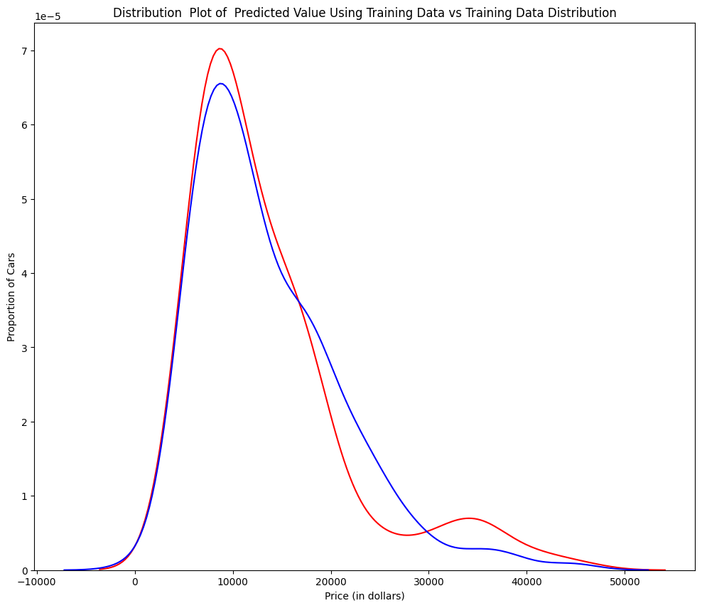

```python
# Let's examine the distribution of the predicted values of the training data.
Title = 'Distribution  Plot of  Predicted Value Using Training Data vs Training Data Distribution'
DistributionPlot(y_train, yhat_train, "Actual Values (Train)", "Predicted Values (Train)", Title)
```

Figure 1: Plot of predicted values using the training data compared to the actual values of the training data.

So far, the model seems to be doing well in learning from the training dataset. But what happens when the model encounters new data from the testing dataset? When the model generates new values from the test data, we see the distribution of the predicted values is much different from the actual target values.

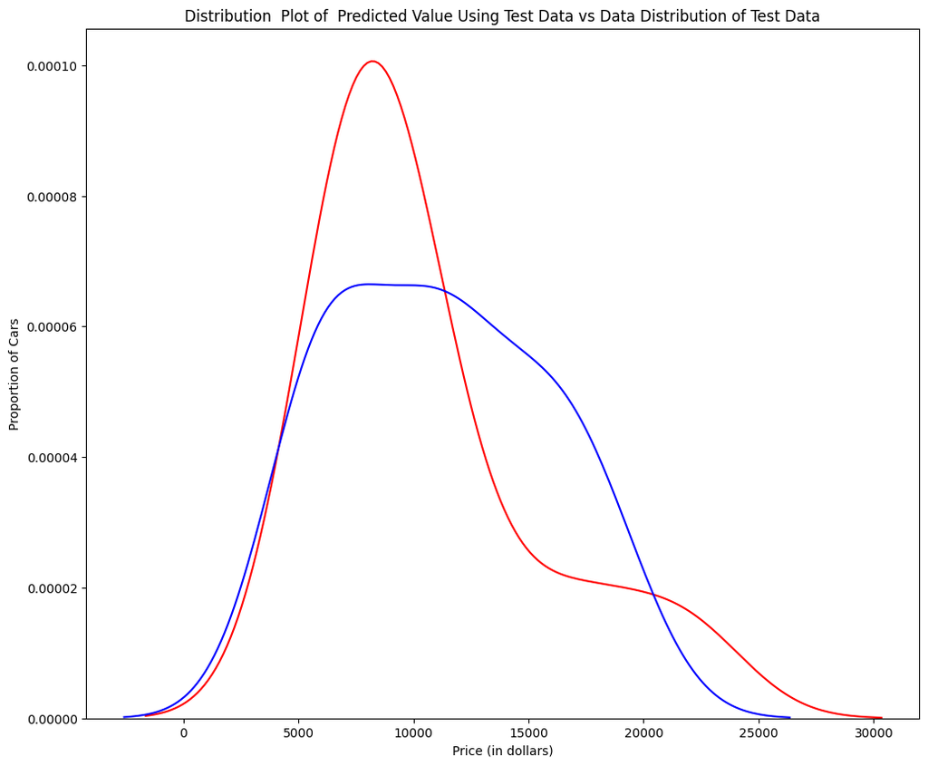

```python
Title='Distribution  Plot of  Predicted Value Using Test Data vs Data Distribution of Test Data'
DistributionPlot(y_test,yhat_test,"Actual Values (Test)","Predicted Values (Test)",Title)
```

Figure 2: Plot of predicted value using the test data compared to the actual values of the test data.

```python
from sklearn.preprocessing import PolynomialFeatures
```

**Overfitting**

Overfitting occurs when the model fits the noise, but not the underlying process. Therefore, when testing your model using the test set, your model does not perform as well since it is modelling noise, not the underlying process that generated the relationship. Let's create a degree 5 polynomial model.

```python
# Let's use 55 percent of the data for training and the rest for testing:
x_train, x_test, y_train, y_test = train_test_split(x_data, y_data, test_size=0.45, random_state=0)

# We will perform a degree 5 polynomial transformation on the feature 'horsepower'.
pr = PolynomialFeatures(degree=5)
x_train_pr = pr.fit_transform(x_train[['horsepower']])
x_test_pr = pr.fit_transform(x_test[['horsepower']])
pr
```

```
PolynomialFeatures(degree=5)
```

```python
# Now, let's create a Linear Regression model "poly" and train it.
poly = LinearRegression()
poly.fit(x_train_pr, y_train)
```

```
LinearRegression()
```

```
Predicted values: [ 6727.58267154  7306.70989608 12213.7082022  18895.03221601]
True values: [ 6295 10698 13860 13499]
```

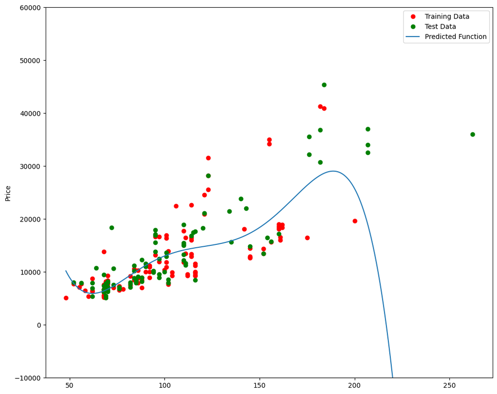

```python
# We can see the output of our model using the method "predict." We assign the values to "yhat".
yhat = poly.predict(x_test_pr)
yhat[0:5]

# Let's take the first five predicted values and compare it to the actual targets.
print("Predicted values:", yhat[0:4])
print("True values:", y_test[0:4].values)

# We will use the function "PollyPlot" that we defined at the beginning of the lab to display the training data,
# testing data, and the predicted function.
PollyPlot(x_train['horsepower'], x_test['horsepower'], y_train, y_test, poly,pr)
```

Figure 3: A polynomial regression model where red dots represent training data, green dots represent test data, and the blue line represents the model prediction.

We see that the estimated function appears to track the data but around 200 horsepower, the function begins to diverge from the data points.

R^2 of the training data:

```python
poly.score(x_train_pr, y_train)
```

```
0.5568527853911671
```

```python
# R^2 of the test data:
poly.score(x_test_pr, y_test)
```

```
-29.815558971873394
```

Let's see how the R^2 changes on the test data for different order polynomials and then plot the results:

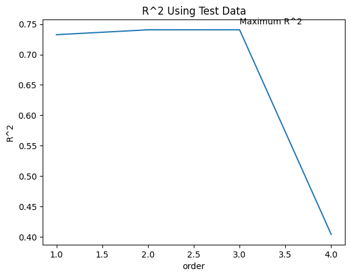

```python
Rsqu_test = []

order = [1, 2, 3, 4]
for n in order:
    pr = PolynomialFeatures(degree=n)

    x_train_pr = pr.fit_transform(x_train[['horsepower']])

    x_test_pr = pr.fit_transform(x_test[['horsepower']])

    lr.fit(x_train_pr, y_train)

    Rsqu_test.append(lr.score(x_test_pr, y_test))

plt.plot(order, Rsqu_test)
plt.xlabel('order')
plt.ylabel('R^2')
plt.title('R^2 Using Test Data')
plt.text(3, 0.75, 'Maximum R^2 ')
```

We see the R^2 gradually increases until an order three polynomial is used. Then, the R^2 dramatically decreases at an order four polynomial.

```python
def f(order, test_data):
    x_train, x_test, y_train, y_test = train_test_split(x_data, y_data, test_size=test_data, random_state=0)
    pr = PolynomialFeatures(degree=order)
    x_train_pr = pr.fit_transform(x_train[['horsepower']])
    x_test_pr = pr.fit_transform(x_test[['horsepower']])
    poly = LinearRegression()
    poly.fit(x_train_pr,y_train)
    PollyPlot(x_train['horsepower'], x_test['horsepower'], y_train, y_test, poly,pr)
```

```python
# The following interface allows you to experiment with different polynomial orders and different amounts of data.
# interact(f, order=(0, 6, 1), test_data=(0.05, 0.95, 0.05))
```

```python
# We can perform polynomial transformations with more than one feature. Create a "PolynomialFeatures" object "pr1" of degree two.
pr1=PolynomialFeatures(degree=2)
```

```python
# Transform the training and testing samples for the features 'horsepower', 'curb-weight', 'engine-size' and 'highway-mpg'. Hint: use the method "fit_transform".
x_train_pr1=pr1.fit_transform(x_train[['horsepower', 'curb-weight', 'engine-size', 'highway-mpg']])

x_test_pr1=pr1.fit_transform(x_test[['horsepower', 'curb-weight', 'engine-size', 'highway-mpg']])
```

```python
# How many dimensions does the new feature have? Hint: use the attribute "shape".
x_train_pr1.shape #there are now 15 features
```

```
(110, 15)
```

```python
# Create a linear regression model "poly1". Train the object using the method "fit" using the polynomial features.
poly1=LinearRegression().fit(x_train_pr1,y_train)
```

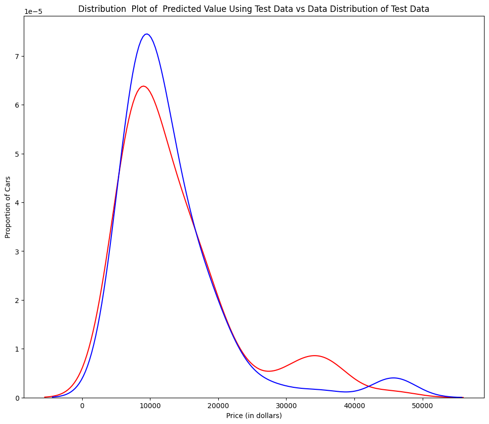

```python
# Use the method "predict" to predict an output on the polynomial features,
# then use the function "DistributionPlot" to display the distribution of the predicted test output vs. the actual test data.
yhat_test1=poly1.predict(x_test_pr1)

Title='Distribution  Plot of  Predicted Value Using Test Data vs Data Distribution of Test Data'

DistributionPlot(y_test, yhat_test1, "Actual Values (Test)", "Predicted Values (Test)", Title)
```

The predicted value is higher than actual value for cars where the price 10,000 range, conversely the predicted price is lower than the price cost in the 30,000 to 40,000 range. As such the model is not as accurate in these ranges.